# ECE 57000 Assignment 08 Exercise

Your Name: David Farache

For this assignment, you will do an ablation study on the DCGAN model discussed in class and implemented WGAN with weight clipping and (optional) WGAN with gradient penalty.

## Exercise 1: Ablation Study on DCGAN

An ablation study measures performance changes after changing certain components in the AI system. The goal is to understand the contribution on each component for the overall system.

### Task 1.0 Original DCGAN on MNIST from class note

Here is the copy of the code implementation from [course website](https://www.davidinouye.com/course/ece57000-fall-2022/lectures/dcgan-mnist-edit.pdf). Please run the code to obtain the result and **use it as a baseline to compare the results** with the following the ablation tasks.

#### Hyper-parameter and Dataloader setup

```
Random Seed:  999
Downloading http://yann.lecun.com/exdb/mnist/train-images-idx3-ubyte.gz
Downloading http://yann.lecun.com/exdb/mnist/train-images-idx3-ubyte.gz to data/MNIST/raw/train-images-idx3-ubyte.gz
```

[output not shown]

[output not shown]

[output not shown]

[output not shown]

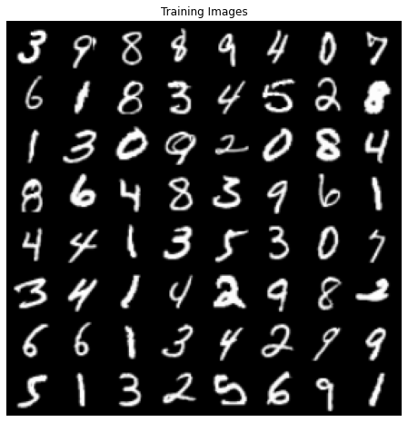

```python
from __future__ import print_function
#%matplotlib inline
import argparse
import os
import random
import torch
import torch.nn as nn
import torch.nn.parallel
import torch.backends.cudnn as cudnn
import torch.optim as optim
import torch.utils.data
import torchvision.datasets as dset
import torchvision.transforms as transforms
import torchvision.utils as vutils
import numpy as np
import matplotlib.pyplot as plt
import matplotlib.animation as animation
from IPython.display import HTML

# Set random seed for reproducibility
manualSeed = 999
#manualSeed = random.randint(1, 10000) # use if you want new results
print("Random Seed: ", manualSeed)
random.seed(manualSeed)
torch.manual_seed(manualSeed)
torch.cuda.manual_seed(manualSeed)
torch.backends.cudnn.deterministic = True
torch.backends.cudnn.benchmarks = False
os.environ['PYTHONHASHSEED'] = str(manualSeed)

# Root directory for dataset
# dataroot = "data/celeba"

# Number of workers for dataloader
workers = 1

# Batch size during training
batch_size = 128

# Spatial size of training images. All images will be resized to this
#   size using a transformer.
#image_size = 64
image_size = 32

# Number of channels in the training images. For color images this is 3
#nc = 3
nc = 1

# Size of z latent vector (i.e. size of generator input)
nz = 100

# Size of feature maps in generator
#ngf = 64
ngf = 8

# Size of feature maps in discriminator
#ndf = 64
ndf = 8

# Number of training epochs
num_epochs = 5
num_epochs_wgan = 15
num_iters = 250

# Learning rate for optimizers
lr = 0.0002
lr_rms = 5e-4

# Beta1 hyperparam for Adam optimizers
beta1 = 0.5

# Number of GPUs available. Use 0 for CPU mode.
ngpu = 1

# Decide which device we want to run on
device = torch.device("cuda:0" if (torch.cuda.is_available() and ngpu > 0) else "cpu")

# Initialize BCELoss function
criterion = nn.BCELoss()

# Create batch of latent vectors that we will use to visualize
# the progression of the generator
fixed_noise = torch.randn(64, nz, 1, 1, device=device)

# Establish convention for real and fake labels during training
real_label = 1.0
fake_label = 0.0

# Several useful functions
def initialize_net(net_class, init_method, device, ngpu):

    # Create the generator
    net_inst = net_class(ngpu).to(device)

    # Handle multi-gpu if desired
    if (device.type == 'cuda') and (ngpu > 1):
        net_inst = nn.DataParallel(net_inst, list(range(ngpu)))

    # Apply the weights_init function to randomly initialize all weights
    #  to mean=0, stdev=0.2.
    if init_method is not None:
        net_inst.apply(init_method)

    # Print the model
    print(net_inst)

    return net_inst

def plot_GAN_loss(losses, labels):

    plt.figure(figsize=(10,5))
    plt.title("Losses During Training")

    for loss, label in zip(losses, labels):
        plt.plot(loss,label=f"{label}")

    plt.xlabel("iterations")
    plt.ylabel("Loss")
    plt.legend()
    plt.show()


def plot_real_fake_images(real_batch, fake_batch):

    # Plot the real images
    plt.figure(figsize=(15,15))
    plt.subplot(1,2,1)
    plt.axis("off")
    plt.title("Real Images")
    plt.imshow(np.transpose(vutils.make_grid(real_batch[0].to(device)[:64], padding=5, normalize=True).cpu(),(1,2,0)))

    # Plot the fake images from the last epoch
    plt.subplot(1,2,2)
    plt.axis("off")
    plt.title("Fake Images")
    plt.imshow(np.transpose(fake_batch[-1],(1,2,0)))
    plt.show()


# custom weights initialization called on netG and netD
def weights_init(m):
    classname = m.__class__.__name__
    if classname.find('Conv') != -1:
        nn.init.normal_(m.weight.data, 0.0, 0.02)
    elif classname.find('BatchNorm') != -1:
        nn.init.normal_(m.weight.data, 1.0, 0.02)
        nn.init.constant_(m.bias.data, 0)

# Download the MNIST dataset
dataset = dset.MNIST(
    'data', train=True, download=True,
   transform=transforms.Compose([
       transforms.Resize(image_size), # Resize from 28 x 28 to 32 x 32 (so power of 2)
       transforms.CenterCrop(image_size),
       transforms.ToTensor(),
       transforms.Normalize((0.5,), (0.5,))
   ]))

# Create the dataloader
dataloader = torch.utils.data.DataLoader(dataset, batch_size=batch_size,
                                         shuffle=True, num_workers=workers)

# Plot some training images
real_batch = next(iter(dataloader))
plt.figure(figsize=(8,8))
plt.axis("off")
plt.title("Training Images")
plt.imshow(np.transpose(vutils.make_grid(real_batch[0].to(device)[:64], padding=2, normalize=True).cpu(),(1,2,0)))
```

#### Architectural design for generator and discriminator

```python
# Generator Code
class Generator(nn.Module):
    def __init__(self, ngpu):
        super(Generator, self).__init__()
        self.ngpu = ngpu
        self.main = nn.Sequential(
            # input is Z, going into a convolution, state size. nz x 1 x 1
            nn.ConvTranspose2d( nz, ngf * 4, kernel_size=4, stride=1, padding=0, bias=False),
            nn.BatchNorm2d(ngf * 4),
            nn.ReLU(True), # inplace ReLU
            # current state size. (ngf*4) x 4 x 4
            nn.ConvTranspose2d(ngf * 4, ngf * 2, 4, 2, 1, bias=False),
            nn.BatchNorm2d(ngf * 2),
            nn.ReLU(True),
            # current state size. (ngf*2) x 8 x 8
            nn.ConvTranspose2d( ngf * 2, ngf, 4, 2, 1, bias=False),
            nn.BatchNorm2d(ngf),
            nn.ReLU(True),
            # current state size. ngf x 16 x 16
            nn.ConvTranspose2d( ngf, nc, 4, 2, 1, bias=False),
            # current state size. nc x 32 x 32
            # Produce number between -1 and 1, as pixel values have been normalized to be between -1 and 1
            nn.Tanh()
        )

    def forward(self, input):
        return self.main(input)


class Discriminator(nn.Module):
    def __init__(self, ngpu):
        super(Discriminator, self).__init__()
        self.ngpu = ngpu
        self.main = nn.Sequential(
            # input is (nc) x 32 x 32
            nn.Conv2d(nc, ndf, 4, 2, 1, bias=False),
            nn.LeakyReLU(0.2, inplace=True),
            # state size. (ndf) x 16 x 16
            nn.Conv2d(ndf, ndf * 2, 4, 2, 1, bias=False),
            nn.BatchNorm2d(ndf * 2),
            nn.LeakyReLU(0.2, inplace=True),
            # state size. (ndf*2) x 8 x 8
            nn.Conv2d(ndf * 2, ndf * 4, 4, 2, 1, bias=False),
            nn.BatchNorm2d(ndf * 4),
            nn.LeakyReLU(0.2, inplace=True),
            # state size. (ndf*4) x 4 x 4
            nn.Conv2d(ndf * 4, 1, 4, 1, 0, bias=False),
            # state size. (ndf*4) x 1 x 1
            nn.Sigmoid()  # Produce probability
        )

    def forward(self, input):
        return self.main(input)
```

#### Loss function and Training function

```python
# Initialize networks
netG = initialize_net(Generator, weights_init, device, ngpu)
netD = initialize_net(Discriminator, weights_init, device, ngpu)

# Setup Adam optimizers for both G and D
optimizerD = optim.Adam(netD.parameters(), lr=lr, betas=(beta1, 0.999))
optimizerG = optim.Adam(netG.parameters(), lr=lr, betas=(beta1, 0.999))

# Training Loop

# Lists to keep track of progress
img_list = []
G_losses = []
D_losses = []
iters = 0

print("Starting Training Loop...")
# For each epoch
for epoch in range(num_epochs):
    # For each batch in the dataloader
    for i, data in enumerate(dataloader, 0):

        ############################
        # (1) Update D network: maximize log(D(x)) + log(1 - D(G(z)))
        ###########################
        ## Train with all-real batch
        netD.zero_grad() #Discriminator zero grad
        # Format batch
        real_cpu = data[0].to(device)
        b_size = real_cpu.size(0)
        label = torch.full((b_size,), real_label, device=device)
        # Forward pass real batch through D
        output = netD(real_cpu).view(-1)
        # Calculate loss on all-real batch
        errD_real = criterion(output, label)
        # Calculate gradients for D in backward pass
        errD_real.backward()
        D_x = output.mean().item()

        ## Train with all-fake batch
        # Generate batch of latent vectors
        noise = torch.randn(b_size, nz, 1, 1, device=device)
        # Generate fake image batch with G
        fake = netG(noise)
        label.fill_(fake_label)
        # Classify all fake batch with D
        output = netD(fake.detach()).view(-1)
        # Calculate D's loss on the all-fake batch
        errD_fake = criterion(output, label)
        # Calculate the gradients for this batch
        errD_fake.backward()
        D_G_z1 = output.mean().item()
        # Add the gradients from the all-real and all-fake batches
        errD = errD_real + errD_fake
        # Update D
        optimizerD.step()

        ############################
        # (2) Update G network: maximize log(D(G(z)))
        ###########################
        netG.zero_grad()
        label.fill_(real_label)  # fake labels are real for generator cost
        # Since we just updated D, perform another forward pass of all-fake batch through D
        output = netD(fake).view(-1)
        # Calculate G's loss based on this output
        errG = criterion(output, label)
        # Calculate gradients for G
        errG.backward()
        D_G_z2 = output.mean().item()
        # Update G
        optimizerG.step()

        # Output training stats
        if i % 50 == 0:
            print('[%d/%d][%d/%d]\tLoss_D: %.4f\tLoss_G: %.4f\tD(x): %.4f\tD(G(z)): %.4f / %.4f'
                  % (epoch, num_epochs, i, len(dataloader),
                     errD.item(), errG.item(), D_x, D_G_z1, D_G_z2))

        # Save Losses for plotting later
        G_losses.append(errG.item())
        D_losses.append(errD.item())

        # Check how the generator is doing by saving G's output on fixed_noise
        if (iters % 500 == 0) or ((epoch == num_epochs-1) and (i == len(dataloader)-1)):
            with torch.no_grad():
                fake = netG(fixed_noise).detach().cpu()
            img_list.append(vutils.make_grid(fake, padding=2, normalize=True))

        iters += 1
```

```
Generator(
  (main): Sequential(
    (0): ConvTranspose2d(100, 32, kernel_size=(4, 4), stride=(1, 1), bias=False)
    (1): BatchNorm2d(32, eps=1e-05, momentum=0.1, affine=True, track_running_stats=True)
    (2): ReLU(inplace=True)
    (3): ConvTranspose2d(32, 16, kernel_size=(4, 4), stride=(2, 2), padding=(1, 1), bias=False)
    (4): BatchNorm2d(16, eps=1e-05, momentum=0.1, affine=True, track_running_stats=True)
    (5): ReLU(inplace=True)
    (6): ConvTranspose2d(16, 8, kernel_size=(4, 4), stride=(2, 2), padding=(1, 1), bias=False)
    (7): BatchNorm2d(8, eps=1e-05, momentum=0.1, affine=True, track_running_stats=True)
    (8): ReLU(inplace=True)
    (9): ConvTranspose2d(8, 1, kernel_size=(4, 4), stride=(2, 2), padding=(1, 1), bias=False)
    (10): Tanh()
  )
)
Discriminator(
  (main): Sequential(
    (0): Conv2d(1, 8, kernel_size=(4, 4), stride=(2, 2), padding=(1, 1), bias=False)
    (1): LeakyReLU(negative_slope=0.2, inplace=True)
    (2): Conv2d(8, 16, kernel_size=(4, 4), stride=(2, 2), padding=(1, 1), bias=False)
    (3): BatchNorm2d(16, eps=1e-05, momentum=0.1, affine=True, track_running_stats=True)
    (4): LeakyReLU(negative_slope=0.2, inplace=True)
    (5): Conv2d(16, 32, kernel_size=(4, 4), stride=(2, 2), padding=(1, 1), bias=False)
    (6): BatchNorm2d(32, eps=1e-05, momentum=0.1, affine=True, track_running_stats=True)
    (7): LeakyReLU(negative_slope=0.2, inplace=True)
    (8): Conv2d(32, 1, kernel_size=(4, 4), stride=(1, 1), bias=False)
    (9): Sigmoid()
  )
)
Starting Training Loop...
[0/5][0/469]	Loss_D: 1.4356	Loss_G: 0.8300	D(x): 0.4446	D(G(z)): 0.4563 / 0.4401
[0/5][50/469]	Loss_D: 0.4836	Loss_G: 1.4891	D(x): 0.8619	D(G(z)): 0.2795 / 0.2321
[0/5][100/469]	Loss_D: 0.2660	Loss_G: 2.5524	D(x): 0.9046	D(G(z)): 0.1479 / 0.0822
[0/5][150/469]	Loss_D: 0.1583	Loss_G: 2.8921	D(x): 0.9316	D(G(z)): 0.0793 / 0.0597
[0/5][200/469]	Loss_D: 0.0980	Loss_G: 3.8191	D(x): 0.9557	D(G(z)): 0.0488 / 0.0236
[0/5][250/469]	Loss_D: 0.0497	Loss_G: 3.9569	D(x): 0.9814	D(G(z)): 0.0302 / 0.0201
[0/5][300/469]	Loss_D: 0.0357	Loss_G: 4.2195	D(x): 0.9855	D(G(z)): 0.0206 / 0.0176
[0/5][350/469]	Loss_D: 0.0210	Loss_G: 4.4884	D(x): 0.9941	D(G(z)): 0.0149 / 0.0131
[0/5][400/469]	Loss_D: 0.0291	Loss_G: 4.5516	D(x): 0.9887	D(G(z)): 0.0174 / 0.0138
[0/5][450/469]	Loss_D: 0.0190	Loss_G: 4.8127	D(x): 0.9942	D(G(z)): 0.0130 / 0.0096
```

[output cut: 25 more lines]

```
[3/5][250/469]	Loss_D: 0.2395	Loss_G: 2.2178	D(x): 0.8572	D(G(z)): 0.0715 / 0.1260
[3/5][300/469]	Loss_D: 0.3882	Loss_G: 1.1191	D(x): 0.7334	D(G(z)): 0.0568 / 0.3549
[3/5][350/469]	Loss_D: 1.4998	Loss_G: 5.1079	D(x): 0.9948	D(G(z)): 0.7391 / 0.0076
[3/5][400/469]	Loss_D: 0.4752	Loss_G: 2.2032	D(x): 0.8532	D(G(z)): 0.2515 / 0.1353
[3/5][450/469]	Loss_D: 0.7158	Loss_G: 0.8740	D(x): 0.5263	D(G(z)): 0.0191 / 0.4377
[4/5][0/469]	Loss_D: 0.3127	Loss_G: 2.8124	D(x): 0.9444	D(G(z)): 0.2174 / 0.0695
[4/5][50/469]	Loss_D: 0.3922	Loss_G: 2.3874	D(x): 0.9300	D(G(z)): 0.2613 / 0.1080
[4/5][100/469]	Loss_D: 0.3196	Loss_G: 1.9244	D(x): 0.8306	D(G(z)): 0.1129 / 0.1714
[4/5][150/469]	Loss_D: 0.3180	Loss_G: 1.7020	D(x): 0.7810	D(G(z)): 0.0490 / 0.2002
[4/5][200/469]	Loss_D: 0.4370	Loss_G: 1.1726	D(x): 0.7011	D(G(z)): 0.0531 / 0.3366
[4/5][250/469]	Loss_D: 0.2673	Loss_G: 2.5591	D(x): 0.9147	D(G(z)): 0.1555 / 0.0881
[4/5][300/469]	Loss_D: 0.4278	Loss_G: 1.7023	D(x): 0.7320	D(G(z)): 0.0822 / 0.2106
[4/5][350/469]	Loss_D: 0.4242	Loss_G: 1.8067	D(x): 0.7583	D(G(z)): 0.1115 / 0.1873
[4/5][400/469]	Loss_D: 0.4098	Loss_G: 1.4749	D(x): 0.7583	D(G(z)): 0.1041 / 0.2566
[4/5][450/469]	Loss_D: 0.2584	Loss_G: 2.6638	D(x): 0.8931	D(G(z)): 0.1272 / 0.0853
```

#### Visualization of the results

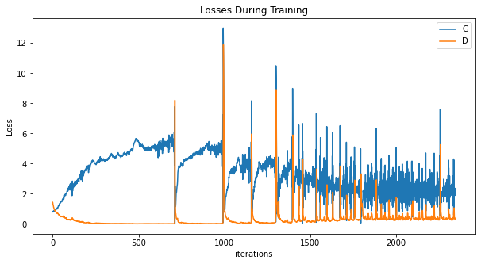

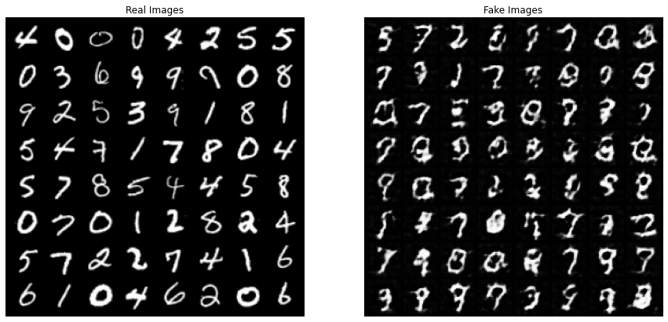

```python
# plot the loss for generator and discriminator
plot_GAN_loss([G_losses, D_losses], ["G", "D"])

# Grab a batch of real images from the dataloader
plot_real_fake_images(next(iter(dataloader)), img_list)
```

### Task 1.1 Ablation study on batch normalization

1. Please modify the code provided in the Task 1.0 so that the neural network architure does not contain any batch normalization layer.  
   Hint: modify the *Architectural design for generator and discriminator* section in Task 1.0
2. Train the model with modified networks and visualize the results.

```python
# Generator Code
class Generator_woBN(nn.Module):
    def __init__(self, ngpu):
        super(Generator_woBN, self).__init__()
        self.ngpu = ngpu
        self.main = nn.Sequential(
            ################################ YOUR CODE ################################
            # input is Z, going into a convolution, state size. nz x 1 x 1
            nn.ConvTranspose2d( nz, ngf * 4, kernel_size=4, stride=1, padding=0, bias=False),
            nn.ReLU(True), # inplace ReLU
            # current state size. (ngf*4) x 4 x 4
            nn.ConvTranspose2d(ngf * 4, ngf * 2, 4, 2, 1, bias=False),
            nn.ReLU(True),
            # current state size. (ngf*2) x 8 x 8
            nn.ConvTranspose2d( ngf * 2, ngf, 4, 2, 1, bias=False),
            nn.ReLU(True),
            # current state size. ngf x 16 x 16
            nn.ConvTranspose2d( ngf, nc, 4, 2, 1, bias=False),
            # current state size. nc x 32 x 32
            # Produce number between -1 and 1, as pixel values have been normalized to be between -1 and 1
            nn.Tanh()
            ############################# END YOUR CODE ##############################
        )

    def forward(self, input):
        return self.main(input)


class Discriminator_woBN(nn.Module):
    def __init__(self, ngpu):
        super(Discriminator_woBN, self).__init__()
        self.ngpu = ngpu
        self.main = nn.Sequential(
            ################################ YOUR CODE ################################
            # input is (nc) x 32 x 32
            nn.Conv2d(nc, ndf, 4, 2, 1, bias=False),
            nn.LeakyReLU(0.2, inplace=True),
            # state size. (ndf) x 16 x 16
            nn.Conv2d(ndf, ndf * 2, 4, 2, 1, bias=False),
            nn.LeakyReLU(0.2, inplace=True),
            # state size. (ndf*2) x 8 x 8
            nn.Conv2d(ndf * 2, ndf * 4, 4, 2, 1, bias=False),
            nn.LeakyReLU(0.2, inplace=True),
            # state size. (ndf*4) x 4 x 4
            nn.Conv2d(ndf * 4, 1, 4, 1, 0, bias=False),
            # state size. (ndf*4) x 1 x 1
            nn.Sigmoid() # Produce probability
            ############################# END YOUR CODE ##############################
        )

    def forward(self, input):
        return self.main(input)

netG_noBN = initialize_net(Generator_woBN, weights_init, device, ngpu)
netD_noBN = initialize_net(Discriminator_woBN, weights_init, device, ngpu)
```

```
Generator_woBN(
  (main): Sequential(
    (0): ConvTranspose2d(100, 32, kernel_size=(4, 4), stride=(1, 1), bias=False)
    (1): ReLU(inplace=True)
    (2): ConvTranspose2d(32, 16, kernel_size=(4, 4), stride=(2, 2), padding=(1, 1), bias=False)
    (3): ReLU(inplace=True)
    (4): ConvTranspose2d(16, 8, kernel_size=(4, 4), stride=(2, 2), padding=(1, 1), bias=False)
    (5): ReLU(inplace=True)
    (6): ConvTranspose2d(8, 1, kernel_size=(4, 4), stride=(2, 2), padding=(1, 1), bias=False)
    (7): Tanh()
  )
)
Discriminator_woBN(
  (main): Sequential(
    (0): Conv2d(1, 8, kernel_size=(4, 4), stride=(2, 2), padding=(1, 1), bias=False)
    (1): LeakyReLU(negative_slope=0.2, inplace=True)
    (2): Conv2d(8, 16, kernel_size=(4, 4), stride=(2, 2), padding=(1, 1), bias=False)
    (3): LeakyReLU(negative_slope=0.2, inplace=True)
    (4): Conv2d(16, 32, kernel_size=(4, 4), stride=(2, 2), padding=(1, 1), bias=False)
    (5): LeakyReLU(negative_slope=0.2, inplace=True)
    (6): Conv2d(32, 1, kernel_size=(4, 4), stride=(1, 1), bias=False)
    (7): Sigmoid()
  )
)
```

```python
# Setup Adam optimizers for both G and D
optimizerD_noBN = optim.Adam(netD_noBN.parameters(), lr=lr, betas=(beta1, 0.999))
optimizerG_noBN = optim.Adam(netG_noBN.parameters(), lr=lr, betas=(beta1, 0.999))

# Training Loop

# Lists to keep track of progress
img_list = []
G_losses = []
D_losses = []
iters = 0

print("Starting Training Loop...")
# For each epoch
for epoch in range(num_epochs):
    # For each batch in the dataloader
    for i, data in enumerate(dataloader, 0):

        ############################
        # (1) Update D network: maximize log(D(x)) + log(1 - D(G(z)))
        ###########################
        ## Train with all-real batch
        netD_noBN.zero_grad()
        # Format batch
        real_cpu = data[0].to(device)
        b_size = real_cpu.size(0)
        label = torch.full((b_size,), real_label, device=device)
        # Forward pass real batch through D
        output = netD_noBN(real_cpu).view(-1)
        # Calculate loss on all-real batch
        errD_real = criterion(output, label)
        # Calculate gradients for D in backward pass
        errD_real.backward()
        D_x = output.mean().item()

        ## Train with all-fake batch
        # Generate batch of latent vectors
        noise = torch.randn(b_size, nz, 1, 1, device=device)
        # Generate fake image batch with G
        fake = netG_noBN(noise)
        label.fill_(fake_label)
        # Classify all fake batch with D
        output = netD_noBN(fake.detach()).view(-1)
        # Calculate D's loss on the all-fake batch
        errD_fake = criterion(output, label)
        # Calculate the gradients for this batch
        errD_fake.backward()
        D_G_z1 = output.mean().item()
        # Add the gradients from the all-real and all-fake batches
        errD = errD_real + errD_fake
        # Update D
        optimizerD_noBN.step()

        ############################
        # (2) Update G network: maximize log(D(G(z)))
        ###########################
        netG_noBN.zero_grad()
        label.fill_(real_label)  # fake labels are real for generator cost
        # Since we just updated D, perform another forward pass of all-fake batch through D
        output = netD_noBN(fake).view(-1)
        # Calculate G's loss based on this output
        errG = criterion(output, label)
        # Calculate gradients for G
        errG.backward()
        D_G_z2 = output.mean().item()
        # Update G
        optimizerG_noBN.step()

        # Output training stats
        if i % 50 == 0:
            print('[%d/%d][%d/%d]\tLoss_D: %.4f\tLoss_G: %.4f\tD(x): %.4f\tD(G(z)): %.4f / %.4f'
                  % (epoch, num_epochs, i, len(dataloader),
                     errD.item(), errG.item(), D_x, D_G_z1, D_G_z2))

        # Save Losses for plotting later
        G_losses.append(errG.item())
        D_losses.append(errD.item())

        # Check how the generator is doing by saving G's output on fixed_noise
        if (iters % 500 == 0) or ((epoch == num_epochs-1) and (i == len(dataloader)-1)):
            with torch.no_grad():
                fake = netG_noBN(fixed_noise).detach().cpu()
            img_list.append(vutils.make_grid(fake, padding=2, normalize=True))

        iters += 1
```

```
Starting Training Loop...
[0/5][0/469]	Loss_D: 1.3863	Loss_G: 0.6931	D(x): 0.5000	D(G(z)): 0.5000 / 0.5000
[0/5][50/469]	Loss_D: 1.1252	Loss_G: 0.4746	D(x): 0.8744	D(G(z)): 0.6283 / 0.6223
[0/5][100/469]	Loss_D: 0.9009	Loss_G: 0.8734	D(x): 0.7190	D(G(z)): 0.4338 / 0.4177
[0/5][150/469]	Loss_D: 0.7232	Loss_G: 0.7295	D(x): 0.9423	D(G(z)): 0.4790 / 0.4826
[0/5][200/469]	Loss_D: 1.0443	Loss_G: 0.4911	D(x): 0.9180	D(G(z)): 0.6116 / 0.6124
[0/5][250/469]	Loss_D: 1.2141	Loss_G: 0.4726	D(x): 0.8034	D(G(z)): 0.6279 / 0.6237
[0/5][300/469]	Loss_D: 1.0106	Loss_G: 0.6387	D(x): 0.7824	D(G(z)): 0.5288 / 0.5281
[0/5][350/469]	Loss_D: 0.6615	Loss_G: 0.7644	D(x): 0.9810	D(G(z)): 0.4733 / 0.4657
[0/5][400/469]	Loss_D: 0.7591	Loss_G: 0.9398	D(x): 0.8156	D(G(z)): 0.4083 / 0.3919
[0/5][450/469]	Loss_D: 0.8376	Loss_G: 0.6363	D(x): 0.9337	D(G(z)): 0.5353 / 0.5295
[1/5][0/469]	Loss_D: 1.0022	Loss_G: 0.5132	D(x): 0.9308	D(G(z)): 0.6042 / 0.5990
[1/5][50/469]	Loss_D: 0.8963	Loss_G: 0.6372	D(x): 0.8856	D(G(z)): 0.5363 / 0.5297
[1/5][100/469]	Loss_D: 1.1010	Loss_G: 0.5057	D(x): 0.8625	D(G(z)): 0.6117 / 0.6039
[1/5][150/469]	Loss_D: 0.9593	Loss_G: 0.6140	D(x): 0.8756	D(G(z)): 0.5591 / 0.5427
[1/5][200/469]	Loss_D: 1.0124	Loss_G: 0.5623	D(x): 0.8573	D(G(z)): 0.5717 / 0.5716
[1/5][250/469]	Loss_D: 0.9936	Loss_G: 0.5743	D(x): 0.8697	D(G(z)): 0.5692 / 0.5652
[1/5][300/469]	Loss_D: 0.9775	Loss_G: 0.5875	D(x): 0.8731	D(G(z)): 0.5657 / 0.5572
[1/5][350/469]	Loss_D: 0.7677	Loss_G: 0.7722	D(x): 0.8887	D(G(z)): 0.4757 / 0.4625
[1/5][400/469]	Loss_D: 0.7927	Loss_G: 0.7660	D(x): 0.8914	D(G(z)): 0.4863 / 0.4664
[1/5][450/469]	Loss_D: 0.7231	Loss_G: 0.8292	D(x): 0.9120	D(G(z)): 0.4631 / 0.4386
[2/5][0/469]	Loss_D: 0.8856	Loss_G: 0.6555	D(x): 0.8812	D(G(z)): 0.5269 / 0.5198
[2/5][50/469]	Loss_D: 0.6933	Loss_G: 0.8428	D(x): 0.9176	D(G(z)): 0.4517 / 0.4316
[2/5][100/469]	Loss_D: 0.8107	Loss_G: 0.6724	D(x): 0.9411	D(G(z)): 0.5235 / 0.5123
[2/5][150/469]	Loss_D: 0.9980	Loss_G: 0.6050	D(x): 0.9410	D(G(z)): 0.6039 / 0.5475
[2/5][200/469]	Loss_D: 0.7916	Loss_G: 0.7367	D(x): 0.8824	D(G(z)): 0.4752 / 0.4814
[2/5][250/469]	Loss_D: 0.9789	Loss_G: 0.5810	D(x): 0.8695	D(G(z)): 0.5497 / 0.5623
[2/5][300/469]	Loss_D: 0.8384	Loss_G: 0.7095	D(x): 0.8726	D(G(z)): 0.4862 / 0.4931
[2/5][350/469]	Loss_D: 0.9776	Loss_G: 0.5762	D(x): 0.8854	D(G(z)): 0.5687 / 0.5637
[2/5][400/469]	Loss_D: 0.9167	Loss_G: 0.6487	D(x): 0.8640	D(G(z)): 0.5247 / 0.5236
[2/5][450/469]	Loss_D: 0.9335	Loss_G: 0.6716	D(x): 0.8591	D(G(z)): 0.5364 / 0.5116
[3/5][0/469]	Loss_D: 0.9312	Loss_G: 0.6650	D(x): 0.8568	D(G(z)): 0.5337 / 0.5151
[3/5][50/469]	Loss_D: 1.0462	Loss_G: 0.5601	D(x): 0.8035	D(G(z)): 0.5542 / 0.5728
[3/5][100/469]	Loss_D: 1.0664	Loss_G: 0.7261	D(x): 0.8837	D(G(z)): 0.6070 / 0.4844
[3/5][150/469]	Loss_D: 0.8818	Loss_G: 0.6989	D(x): 0.8244	D(G(z)): 0.4911 / 0.4980
[3/5][200/469]	Loss_D: 0.9812	Loss_G: 0.6453	D(x): 0.8520	D(G(z)): 0.5556 / 0.5252
[3/5][250/469]	Loss_D: 1.0175	Loss_G: 0.6718	D(x): 0.8607	D(G(z)): 0.5766 / 0.5117
[3/5][300/469]	Loss_D: 1.0496	Loss_G: 0.7817	D(x): 0.9287	D(G(z)): 0.6202 / 0.4586
[3/5][350/469]	Loss_D: 0.8634	Loss_G: 0.6722	D(x): 0.8416	D(G(z)): 0.4932 / 0.5116
[3/5][400/469]	Loss_D: 0.8508	Loss_G: 0.7891	D(x): 0.8310	D(G(z)): 0.4806 / 0.4559
[3/5][450/469]	Loss_D: 0.9617	Loss_G: 0.6548	D(x): 0.7620	D(G(z)): 0.4896 / 0.5216
[4/5][0/469]	Loss_D: 0.8637	Loss_G: 0.8032	D(x): 0.8524	D(G(z)): 0.4997 / 0.4499
[4/5][50/469]	Loss_D: 0.9196	Loss_G: 0.7775	D(x): 0.8726	D(G(z)): 0.5372 / 0.4621
[4/5][100/469]	Loss_D: 0.9168	Loss_G: 0.7162	D(x): 0.8092	D(G(z)): 0.4975 / 0.4902
[4/5][150/469]	Loss_D: 0.9543	Loss_G: 0.6070	D(x): 0.8138	D(G(z)): 0.5194 / 0.5471
[4/5][200/469]	Loss_D: 1.0033	Loss_G: 0.6673	D(x): 0.8430	D(G(z)): 0.5585 / 0.5148
[4/5][250/469]	Loss_D: 1.0301	Loss_G: 0.5354	D(x): 0.7882	D(G(z)): 0.5364 / 0.5874
[4/5][300/469]	Loss_D: 1.0842	Loss_G: 0.7086	D(x): 0.9130	D(G(z)): 0.6248 / 0.4936
[4/5][350/469]	Loss_D: 0.9945	Loss_G: 0.6375	D(x): 0.8169	D(G(z)): 0.5399 / 0.5301
[4/5][400/469]	Loss_D: 1.0111	Loss_G: 0.5356	D(x): 0.7099	D(G(z)): 0.4737 / 0.5872
[4/5][450/469]	Loss_D: 0.9754	Loss_G: 0.6502	D(x): 0.8495	D(G(z)): 0.5502 / 0.5231
```

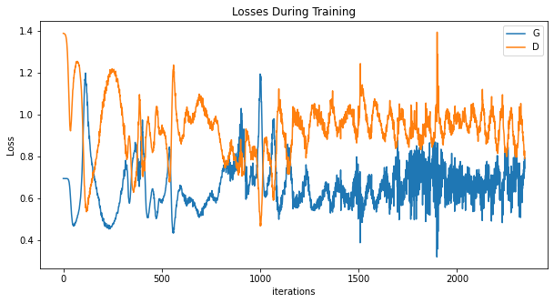

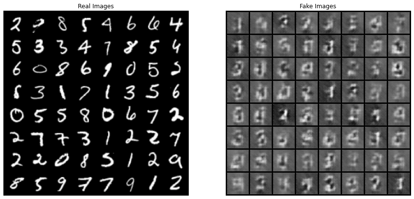

```python
# plot the loss for generator and discriminator
plot_GAN_loss([G_losses, D_losses], ["G", "D"])

# Grab a batch of real images from the dataloader
plot_real_fake_images(next(iter(dataloader)), img_list)
```

### Task 1.2 Ablation study on the trick: "Construct different mini-batches for real and fake"

1. Please modify the code provided in the Task 1.0 so that the discriminator algorithm part computes the forward and backward pass for fake and real images concatenated together (with their corresponding fake and real labels concatenated as well) instead of computing the forward and backward passes for fake and real images separately.  
   Hint: modify the *Loss function and Training function* section in Task 1.0.
2. Train the model with modified networks and visualize the results.

```python
# re-initilizate networks for the generator and discrimintor.
netG = initialize_net(Generator, weights_init, device, ngpu)
netD = initialize_net(Discriminator, weights_init, device, ngpu)

# Setup Adam optimizers for both G and D
optimizerD = optim.Adam(netD.parameters(), lr=lr, betas=(beta1, 0.999))
optimizerG = optim.Adam(netG.parameters(), lr=lr, betas=(beta1, 0.999))

# Training Loop

# Lists to keep track of progress
img_list = []
G_losses = []
D_losses = []
iters = 0

print("Starting Training Loop...")
# For each epoch
for epoch in range(num_epochs):
    # For each batch in the dataloader
    for i, data in enumerate(dataloader, 0):

        ############################
        # (1) Update D network: maximize log(D(x)) + log(1 - D(G(z)))
        ###########################

        ################################ YOUR CODE ################################
        ## Train with all-real batch
        netD.zero_grad()
        real_cpu = data[0].to(device)
        b_size = real_cpu.size(0)

        #noise
        noise = torch.randn(b_size, nz, 1, 1, device=device)
        fake = netG(noise)

        #set labels and concat
        fakeLabel = torch.full((b_size,), fake_label, device=device)
        realLabel = torch.full((b_size,), real_label, device=device)
        label = torch.cat([realLabel, fakeLabel], dim=0)

        # Forward pass real batch through D
        fake_cpu = fake.detach()
        output = netD(torch.cat([real_cpu, fake_cpu], dim=0)).view(-1)

        # Calculate loss on all-real batch
        errD = criterion(output, label)

        # Calculate gradients for D in backward pass
        errD.backward()
        optimizerD.step()
        D_x = output.mean().item()

        ############################ END YOUR CODE ##############################

        ############################
        # (2) Update G network: maximize log(D(G(z)))
        ###########################
        netG.zero_grad()
        label = torch.full((b_size,), real_label, device=device)  # fake labels are real for generator cost
        # Since we just updated D, perform another forward pass of all-fake batch through D
        output = netD(fake).view(-1)
        # Calculate G's loss based on this output
        errG = criterion(output, label)
        # Calculate gradients for G
        errG.backward()
        D_G_z2 = output.mean().item()
        # Update G
        optimizerG.step()

        # Output training stats
        if i % 50 == 0:
            print('[%d/%d][%d/%d]\tLoss_D: %.4f\tLoss_G: %.4f\tD(G(z)): %.4f'
                  % (epoch, num_epochs, i, len(dataloader),
                     errD.item(), errG.item(), D_G_z2))

        # Save Losses for plotting later
        G_losses.append(errG.item())
        D_losses.append(errD.item())

        # Check how the generator is doing by saving G's output on fixed_noise
        if (iters % 500 == 0) or ((epoch == num_epochs-1) and (i == len(dataloader)-1)):
            with torch.no_grad():
                fake = netG(fixed_noise).detach().cpu()
            img_list.append(vutils.make_grid(fake, padding=2, normalize=True))

        iters += 1
```

```
Generator(
  (main): Sequential(
    (0): ConvTranspose2d(100, 32, kernel_size=(4, 4), stride=(1, 1), bias=False)
    (1): BatchNorm2d(32, eps=1e-05, momentum=0.1, affine=True, track_running_stats=True)
    (2): ReLU(inplace=True)
    (3): ConvTranspose2d(32, 16, kernel_size=(4, 4), stride=(2, 2), padding=(1, 1), bias=False)
    (4): BatchNorm2d(16, eps=1e-05, momentum=0.1, affine=True, track_running_stats=True)
    (5): ReLU(inplace=True)
    (6): ConvTranspose2d(16, 8, kernel_size=(4, 4), stride=(2, 2), padding=(1, 1), bias=False)
    (7): BatchNorm2d(8, eps=1e-05, momentum=0.1, affine=True, track_running_stats=True)
    (8): ReLU(inplace=True)
    (9): ConvTranspose2d(8, 1, kernel_size=(4, 4), stride=(2, 2), padding=(1, 1), bias=False)
    (10): Tanh()
  )
)
Discriminator(
  (main): Sequential(
    (0): Conv2d(1, 8, kernel_size=(4, 4), stride=(2, 2), padding=(1, 1), bias=False)
    (1): LeakyReLU(negative_slope=0.2, inplace=True)
    (2): Conv2d(8, 16, kernel_size=(4, 4), stride=(2, 2), padding=(1, 1), bias=False)
    (3): BatchNorm2d(16, eps=1e-05, momentum=0.1, affine=True, track_running_stats=True)
    (4): LeakyReLU(negative_slope=0.2, inplace=True)
    (5): Conv2d(16, 32, kernel_size=(4, 4), stride=(2, 2), padding=(1, 1), bias=False)
    (6): BatchNorm2d(32, eps=1e-05, momentum=0.1, affine=True, track_running_stats=True)
    (7): LeakyReLU(negative_slope=0.2, inplace=True)
    (8): Conv2d(32, 1, kernel_size=(4, 4), stride=(1, 1), bias=False)
    (9): Sigmoid()
  )
)
Starting Training Loop...
[0/5][0/469]	Loss_D: 0.7255	Loss_G: 0.6894	D(G(z)): 0.5058
[0/5][50/469]	Loss_D: 0.0382	Loss_G: 0.0872	D(G(z)): 0.9168
[0/5][100/469]	Loss_D: 0.0122	Loss_G: 0.0418	D(G(z)): 0.9591
[0/5][150/469]	Loss_D: 0.0067	Loss_G: 0.0259	D(G(z)): 0.9744
[0/5][200/469]	Loss_D: 0.0042	Loss_G: 0.0175	D(G(z)): 0.9827
[0/5][250/469]	Loss_D: 0.0029	Loss_G: 0.0129	D(G(z)): 0.9872
[0/5][300/469]	Loss_D: 0.0022	Loss_G: 0.0101	D(G(z)): 0.9900
[0/5][350/469]	Loss_D: 0.0017	Loss_G: 0.0082	D(G(z)): 0.9918
[0/5][400/469]	Loss_D: 0.0014	Loss_G: 0.0070	D(G(z)): 0.9931
[0/5][450/469]	Loss_D: 0.0012	Loss_G: 0.0058	D(G(z)): 0.9942
```

[output cut: 25 more lines]

```
[3/5][250/469]	Loss_D: 0.0001	Loss_G: 0.0007	D(G(z)): 0.9993
[3/5][300/469]	Loss_D: 0.0001	Loss_G: 0.0007	D(G(z)): 0.9993
[3/5][350/469]	Loss_D: 0.0001	Loss_G: 0.0007	D(G(z)): 0.9993
[3/5][400/469]	Loss_D: 0.0001	Loss_G: 0.0006	D(G(z)): 0.9994
[3/5][450/469]	Loss_D: 0.0001	Loss_G: 0.0006	D(G(z)): 0.9994
[4/5][0/469]	Loss_D: 0.0001	Loss_G: 0.0006	D(G(z)): 0.9994
[4/5][50/469]	Loss_D: 0.0001	Loss_G: 0.0006	D(G(z)): 0.9994
[4/5][100/469]	Loss_D: 0.0001	Loss_G: 0.0005	D(G(z)): 0.9995
[4/5][150/469]	Loss_D: 0.0001	Loss_G: 0.0005	D(G(z)): 0.9995
[4/5][200/469]	Loss_D: 0.0001	Loss_G: 0.0005	D(G(z)): 0.9995
[4/5][250/469]	Loss_D: 0.0001	Loss_G: 0.0005	D(G(z)): 0.9995
[4/5][300/469]	Loss_D: 0.0001	Loss_G: 0.0004	D(G(z)): 0.9996
[4/5][350/469]	Loss_D: 0.0001	Loss_G: 0.0004	D(G(z)): 0.9996
[4/5][400/469]	Loss_D: 0.0001	Loss_G: 0.0004	D(G(z)): 0.9996
[4/5][450/469]	Loss_D: 0.0001	Loss_G: 0.0004	D(G(z)): 0.9996
```

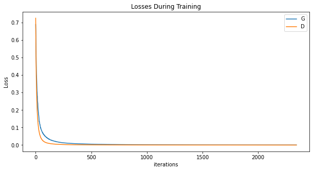

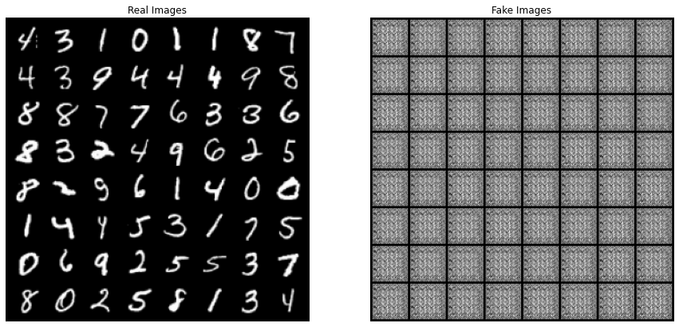

```python
# plot the loss for generator and discriminator
plot_GAN_loss([G_losses, D_losses], ["G", "D"])

# Grab a batch of real images from the dataloader
plot_real_fake_images(next(iter(dataloader)), img_list)
```

### Task 1.3 Ablation study on the generator's loss function

1. Please modify the code provided in the Task 1.0 so that the *Generator* algorithm part minimizes $\log(1-D(G(z)))$ instead of the modified loss function suggested in the original GAN paper of $-\log(D(G(z)))$.
   1. Modify the *Loss function and Training function* section in Task 1.0
   2. (Hint) Try to understand the definition of [BCE loss](https://pytorch.org/docs/stable/generated/torch.nn.BCELoss.html) first and how the modified loss function was implemented.
2. Train the model with modified networks and visualize the results.

```python
# re-initilizate networks for the generator and discrimintor.
netG = initialize_net(Generator, weights_init, device, ngpu)
netD = initialize_net(Discriminator, weights_init, device, ngpu)

# Setup Adam optimizers for both G and D
optimizerD = optim.Adam(netD.parameters(), lr=lr, betas=(beta1, 0.999))
optimizerG = optim.Adam(netG.parameters(), lr=lr, betas=(beta1, 0.999))

# Training Loop

# Lists to keep track of progress
img_list = []
G_losses = []
D_losses = []
iters = 0

print("Starting Training Loop...")
# For each epoch
for epoch in range(num_epochs):
    # For each batch in the dataloader
    for i, data in enumerate(dataloader, 0):

        ############################
        # (1) Update D network: maximize log(D(x)) + log(1 - D(G(z)))
        ###########################
        ## Train with all-real batch
        netD.zero_grad()
        # Format batch
        real_cpu = data[0].to(device)
        b_size = real_cpu.size(0)
        label = torch.full((b_size,), real_label, device=device)
        # Forward pass real batch through D
        output = netD(real_cpu).view(-1)
        # Calculate loss on all-real batch
        errD_real = criterion(output, label)
        # Calculate gradients for D in backward pass
        errD_real.backward()
        D_x = output.mean().item()

        ## Train with all-fake batch
        # Generate batch of latent vectors
        noise = torch.randn(b_size, nz, 1, 1, device=device)
        # Generate fake image batch with G
        fake = netG(noise)
        label.fill_(fake_label)
        # Classify all fake batch with D
        output = netD(fake.detach()).view(-1)
        # Calculate D's loss on the all-fake batch
        errD_fake = criterion(output, label)
        # Calculate the gradients for this batch
        errD_fake.backward()
        D_G_z1 = output.mean().item()
        # Add the gradients from the all-real and all-fake batches
        errD = errD_real + errD_fake
        # Update D
        optimizerD.step()

        ############################
        # (2) Update G network
        ###########################

        ################################ YOUR CODE ################################
        netG.zero_grad()
        label = torch.full((b_size,), real_label, device=device)  # fake labels are real for generator cost
        # Since we just updated D, perform another forward pass of all-fake batch through D
        output = netD(fake).view(-1)
        # Calculate G's loss based on this output
        errG = -1*criterion(output, label)
        # Calculate gradients for G
        errG.backward()
        D_G_z2 = output.mean().item()
        # Update G
        optimizerG.step()
        ############################ END YOUR CODE ##############################

        # Output training stats
        if i % 50 == 0:
            print('[%d/%d][%d/%d]\tLoss_D: %.4f\tLoss_G: %.4f\tD(x): %.4f\tD(G(z)): %.4f / %.4f'
                  % (epoch, num_epochs, i, len(dataloader),
                     errD.item(), errG.item(), D_x, D_G_z1, D_G_z2))

        # Save Losses for plotting later
        G_losses.append(errG.item())
        D_losses.append(errD.item())

        # Check how the generator is doing by saving G's output on fixed_noise
        if (iters % 500 == 0) or ((epoch == num_epochs-1) and (i == len(dataloader)-1)):
            with torch.no_grad():
                fake = netG(fixed_noise).detach().cpu()
            img_list.append(vutils.make_grid(fake, padding=2, normalize=True))

        iters += 1
```

```
Generator(
  (main): Sequential(
    (0): ConvTranspose2d(100, 32, kernel_size=(4, 4), stride=(1, 1), bias=False)
    (1): BatchNorm2d(32, eps=1e-05, momentum=0.1, affine=True, track_running_stats=True)
    (2): ReLU(inplace=True)
    (3): ConvTranspose2d(32, 16, kernel_size=(4, 4), stride=(2, 2), padding=(1, 1), bias=False)
    (4): BatchNorm2d(16, eps=1e-05, momentum=0.1, affine=True, track_running_stats=True)
    (5): ReLU(inplace=True)
    (6): ConvTranspose2d(16, 8, kernel_size=(4, 4), stride=(2, 2), padding=(1, 1), bias=False)
    (7): BatchNorm2d(8, eps=1e-05, momentum=0.1, affine=True, track_running_stats=True)
    (8): ReLU(inplace=True)
    (9): ConvTranspose2d(8, 1, kernel_size=(4, 4), stride=(2, 2), padding=(1, 1), bias=False)
    (10): Tanh()
  )
)
Discriminator(
  (main): Sequential(
    (0): Conv2d(1, 8, kernel_size=(4, 4), stride=(2, 2), padding=(1, 1), bias=False)
    (1): LeakyReLU(negative_slope=0.2, inplace=True)
    (2): Conv2d(8, 16, kernel_size=(4, 4), stride=(2, 2), padding=(1, 1), bias=False)
    (3): BatchNorm2d(16, eps=1e-05, momentum=0.1, affine=True, track_running_stats=True)
    (4): LeakyReLU(negative_slope=0.2, inplace=True)
    (5): Conv2d(16, 32, kernel_size=(4, 4), stride=(2, 2), padding=(1, 1), bias=False)
    (6): BatchNorm2d(32, eps=1e-05, momentum=0.1, affine=True, track_running_stats=True)
    (7): LeakyReLU(negative_slope=0.2, inplace=True)
    (8): Conv2d(32, 1, kernel_size=(4, 4), stride=(1, 1), bias=False)
    (9): Sigmoid()
  )
)
Starting Training Loop...
[0/5][0/469]	Loss_D: 1.5577	Loss_G: -0.6094	D(x): 0.5045	D(G(z)): 0.5744 / 0.5478
[0/5][50/469]	Loss_D: 0.0332	Loss_G: -4.6678	D(x): 0.9771	D(G(z)): 0.0099 / 0.0097
[0/5][100/469]	Loss_D: 0.0114	Loss_G: -5.7986	D(x): 0.9917	D(G(z)): 0.0031 / 0.0031
[0/5][150/469]	Loss_D: 0.0063	Loss_G: -6.4587	D(x): 0.9953	D(G(z)): 0.0016 / 0.0016
[0/5][200/469]	Loss_D: 0.0044	Loss_G: -6.8808	D(x): 0.9967	D(G(z)): 0.0010 / 0.0010
[0/5][250/469]	Loss_D: 0.0030	Loss_G: -7.1899	D(x): 0.9978	D(G(z)): 0.0008 / 0.0008
[0/5][300/469]	Loss_D: 0.0024	Loss_G: -7.4322	D(x): 0.9983	D(G(z)): 0.0006 / 0.0006
[0/5][350/469]	Loss_D: 0.0019	Loss_G: -7.6377	D(x): 0.9986	D(G(z)): 0.0005 / 0.0005
[0/5][400/469]	Loss_D: 0.0016	Loss_G: -7.8202	D(x): 0.9988	D(G(z)): 0.0004 / 0.0004
[0/5][450/469]	Loss_D: 0.0013	Loss_G: -7.9833	D(x): 0.9990	D(G(z)): 0.0003 / 0.0003
```

[output cut: 24 more lines]

[output not shown]

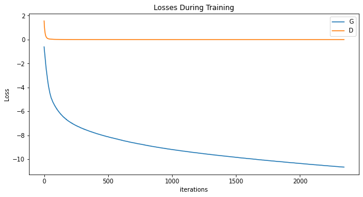

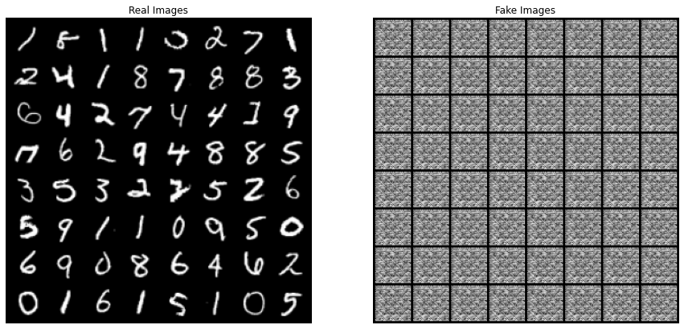

```python
# plot the loss for generator and discriminator
plot_GAN_loss([G_losses, D_losses], ["G", "D"])

# Grab a batch of real images from the dataloader
plot_real_fake_images(next(iter(dataloader)), img_list)
```

### Task 1.4 Ablation study on the weight initialization

1. Please use the function `initialize_net` provided in Task 1.0 to initialize the generator and discriminator function without weight initialization (HINT: There is no need to modify the code for `initialize_net` function).
2. Train the model with modified networks and visualize the results.

```python
################################ YOUR CODE ################################
netG_woinit = initialize_net(Generator, None, device, ngpu)
netD_woinit = initialize_net(Discriminator, None, device, ngpu)
###########################  END YOUR CODE ###############################
```

```
Generator(
  (main): Sequential(
    (0): ConvTranspose2d(100, 32, kernel_size=(4, 4), stride=(1, 1), bias=False)
    (1): BatchNorm2d(32, eps=1e-05, momentum=0.1, affine=True, track_running_stats=True)
    (2): ReLU(inplace=True)
    (3): ConvTranspose2d(32, 16, kernel_size=(4, 4), stride=(2, 2), padding=(1, 1), bias=False)
    (4): BatchNorm2d(16, eps=1e-05, momentum=0.1, affine=True, track_running_stats=True)
    (5): ReLU(inplace=True)
    (6): ConvTranspose2d(16, 8, kernel_size=(4, 4), stride=(2, 2), padding=(1, 1), bias=False)
    (7): BatchNorm2d(8, eps=1e-05, momentum=0.1, affine=True, track_running_stats=True)
    (8): ReLU(inplace=True)
    (9): ConvTranspose2d(8, 1, kernel_size=(4, 4), stride=(2, 2), padding=(1, 1), bias=False)
    (10): Tanh()
  )
)
Discriminator(
  (main): Sequential(
    (0): Conv2d(1, 8, kernel_size=(4, 4), stride=(2, 2), padding=(1, 1), bias=False)
    (1): LeakyReLU(negative_slope=0.2, inplace=True)
    (2): Conv2d(8, 16, kernel_size=(4, 4), stride=(2, 2), padding=(1, 1), bias=False)
    (3): BatchNorm2d(16, eps=1e-05, momentum=0.1, affine=True, track_running_stats=True)
    (4): LeakyReLU(negative_slope=0.2, inplace=True)
    (5): Conv2d(16, 32, kernel_size=(4, 4), stride=(2, 2), padding=(1, 1), bias=False)
    (6): BatchNorm2d(32, eps=1e-05, momentum=0.1, affine=True, track_running_stats=True)
    (7): LeakyReLU(negative_slope=0.2, inplace=True)
    (8): Conv2d(32, 1, kernel_size=(4, 4), stride=(1, 1), bias=False)
    (9): Sigmoid()
  )
)
```

```python
# Setup Adam optimizers for both G and D
optimizerD_woinit = optim.Adam(netD_woinit.parameters(), lr=lr, betas=(beta1, 0.999))
optimizerG_woinit = optim.Adam(netG_woinit.parameters(), lr=lr, betas=(beta1, 0.999))

# Training Loop

# Lists to keep track of progress
img_list = []
G_losses = []
D_losses = []
iters = 0

print("Starting Training Loop...")
# For each epoch
for epoch in range(num_epochs):
    # For each batch in the dataloader
    for i, data in enumerate(dataloader, 0):

        ############################
        # (1) Update D network: maximize log(D(x)) + log(1 - D(G(z)))
        ###########################
        ## Train with all-real batch
        netD_woinit.zero_grad()
        # Format batch
        real_cpu = data[0].to(device)
        b_size = real_cpu.size(0)
        label = torch.full((b_size,), real_label, device=device)
        # Forward pass real batch through D
        output = netD_woinit(real_cpu).view(-1)
        # Calculate loss on all-real batch
        errD_real = criterion(output, label)
        # Calculate gradients for D in backward pass
        errD_real.backward()
        D_x = output.mean().item()

        ## Train with all-fake batch
        # Generate batch of latent vectors
        noise = torch.randn(b_size, nz, 1, 1, device=device)
        # Generate fake image batch with G
        fake = netG_woinit(noise)
        label.fill_(fake_label)
        # Classify all fake batch with D
        output = netD_woinit(fake.detach()).view(-1)
        # Calculate D's loss on the all-fake batch
        errD_fake = criterion(output, label)
        # Calculate the gradients for this batch
        errD_fake.backward()
        D_G_z1 = output.mean().item()
        # Add the gradients from the all-real and all-fake batches
        errD = errD_real + errD_fake
        # Update D
        optimizerD_woinit.step()

        ############################
        # (2) Update G network: maximize log(D(G(z)))
        ###########################
        netG_woinit.zero_grad()
        label.fill_(real_label)  # fake labels are real for generator cost
        # Since we just updated D, perform another forward pass of all-fake batch through D
        output = netD_woinit(fake).view(-1)
        # Calculate G's loss based on this output
        errG = criterion(output, label)
        # Calculate gradients for G
        errG.backward()
        D_G_z2 = output.mean().item()
        # Update G
        optimizerG_woinit.step()

        # Output training stats
        if i % 50 == 0:
            print('[%d/%d][%d/%d]\tLoss_D: %.4f\tLoss_G: %.4f\tD(x): %.4f\tD(G(z)): %.4f / %.4f'
                  % (epoch, num_epochs, i, len(dataloader),
                     errD.item(), errG.item(), D_x, D_G_z1, D_G_z2))

        # Save Losses for plotting later
        G_losses.append(errG.item())
        D_losses.append(errD.item())

        # Check how the generator is doing by saving G's output on fixed_noise
        if (iters % 500 == 0) or ((epoch == num_epochs-1) and (i == len(dataloader)-1)):
            with torch.no_grad():
                fake = netG_woinit(fixed_noise).detach().cpu()
            img_list.append(vutils.make_grid(fake, padding=2, normalize=True))

        iters += 1
```

```
Starting Training Loop...
[0/5][0/469]	Loss_D: 1.4529	Loss_G: 0.8157	D(x): 0.4429	D(G(z)): 0.4549 / 0.4499
[0/5][50/469]	Loss_D: 0.5219	Loss_G: 1.2672	D(x): 0.8670	D(G(z)): 0.3115 / 0.2882
[0/5][100/469]	Loss_D: 0.3789	Loss_G: 1.7409	D(x): 0.8787	D(G(z)): 0.2148 / 0.1887
[0/5][150/469]	Loss_D: 0.3380	Loss_G: 2.0512	D(x): 0.8732	D(G(z)): 0.1728 / 0.1416
[0/5][200/469]	Loss_D: 0.1595	Loss_G: 2.7718	D(x): 0.9416	D(G(z)): 0.0927 / 0.0686
[0/5][250/469]	Loss_D: 0.2329	Loss_G: 2.5527	D(x): 0.8876	D(G(z)): 0.0978 / 0.0870
[0/5][300/469]	Loss_D: 0.1688	Loss_G: 2.9658	D(x): 0.9342	D(G(z)): 0.0861 / 0.0573
[0/5][350/469]	Loss_D: 0.0909	Loss_G: 3.5428	D(x): 0.9605	D(G(z)): 0.0475 / 0.0320
[0/5][400/469]	Loss_D: 0.0587	Loss_G: 3.9742	D(x): 0.9741	D(G(z)): 0.0311 / 0.0219
[0/5][450/469]	Loss_D: 0.0636	Loss_G: 3.9746	D(x): 0.9753	D(G(z)): 0.0373 / 0.0216
[1/5][0/469]	Loss_D: 0.0905	Loss_G: 3.8851	D(x): 0.9657	D(G(z)): 0.0516 / 0.0233
[1/5][50/469]	Loss_D: 0.0557	Loss_G: 4.1384	D(x): 0.9693	D(G(z)): 0.0237 / 0.0184
[1/5][100/469]	Loss_D: 0.0688	Loss_G: 3.8559	D(x): 0.9699	D(G(z)): 0.0350 / 0.0250
[1/5][150/469]	Loss_D: 0.0639	Loss_G: 4.2083	D(x): 0.9660	D(G(z)): 0.0273 / 0.0210
[1/5][200/469]	Loss_D: 0.1353	Loss_G: 3.5539	D(x): 0.9295	D(G(z)): 0.0524 / 0.0408
[1/5][250/469]	Loss_D: 0.1266	Loss_G: 3.3888	D(x): 0.9162	D(G(z)): 0.0282 / 0.0398
[1/5][300/469]	Loss_D: 0.1225	Loss_G: 3.1070	D(x): 0.9446	D(G(z)): 0.0599 / 0.0533
[1/5][350/469]	Loss_D: 0.1034	Loss_G: 3.7115	D(x): 0.9644	D(G(z)): 0.0625 / 0.0296
[1/5][400/469]	Loss_D: 0.1072	Loss_G: 3.7753	D(x): 0.9642	D(G(z)): 0.0646 / 0.0284
[1/5][450/469]	Loss_D: 0.1428	Loss_G: 3.3455	D(x): 0.9250	D(G(z)): 0.0329 / 0.0437
[2/5][0/469]	Loss_D: 0.1096	Loss_G: 3.1085	D(x): 0.9415	D(G(z)): 0.0434 / 0.0544
[2/5][50/469]	Loss_D: 0.0805	Loss_G: 3.6308	D(x): 0.9668	D(G(z)): 0.0435 / 0.0317
[2/5][100/469]	Loss_D: 0.1085	Loss_G: 3.5330	D(x): 0.9396	D(G(z)): 0.0388 / 0.0379
[2/5][150/469]	Loss_D: 0.1479	Loss_G: 2.9561	D(x): 0.9093	D(G(z)): 0.0411 / 0.0637
[2/5][200/469]	Loss_D: 0.0980	Loss_G: 3.5779	D(x): 0.9423	D(G(z)): 0.0348 / 0.0350
[2/5][250/469]	Loss_D: 0.0868	Loss_G: 3.8332	D(x): 0.9511	D(G(z)): 0.0289 / 0.0338
[2/5][300/469]	Loss_D: 0.1138	Loss_G: 3.5660	D(x): 0.9289	D(G(z)): 0.0339 / 0.0388
[2/5][350/469]	Loss_D: 0.1048	Loss_G: 3.4794	D(x): 0.9432	D(G(z)): 0.0401 / 0.0404
[2/5][400/469]	Loss_D: 0.1434	Loss_G: 3.4661	D(x): 0.9507	D(G(z)): 0.0833 / 0.0405
[2/5][450/469]	Loss_D: 0.0673	Loss_G: 4.0064	D(x): 0.9640	D(G(z)): 0.0291 / 0.0239
[3/5][0/469]	Loss_D: 0.1241	Loss_G: 3.2686	D(x): 0.9504	D(G(z)): 0.0669 / 0.0484
[3/5][50/469]	Loss_D: 0.1459	Loss_G: 3.0814	D(x): 0.9479	D(G(z)): 0.0838 / 0.0556
[3/5][100/469]	Loss_D: 0.1101	Loss_G: 3.3787	D(x): 0.9580	D(G(z)): 0.0621 / 0.0412
[3/5][150/469]	Loss_D: 0.1332	Loss_G: 3.2624	D(x): 0.9277	D(G(z)): 0.0450 / 0.0457
[3/5][200/469]	Loss_D: 0.1375	Loss_G: 2.6373	D(x): 0.9285	D(G(z)): 0.0574 / 0.0871
[3/5][250/469]	Loss_D: 0.1586	Loss_G: 3.3186	D(x): 0.9446	D(G(z)): 0.0913 / 0.0488
[3/5][300/469]	Loss_D: 0.1673	Loss_G: 3.0475	D(x): 0.8828	D(G(z)): 0.0265 / 0.0637
[3/5][350/469]	Loss_D: 0.1521	Loss_G: 2.8569	D(x): 0.9220	D(G(z)): 0.0609 / 0.0749
[3/5][400/469]	Loss_D: 0.2083	Loss_G: 3.6813	D(x): 0.9603	D(G(z)): 0.1470 / 0.0337
[3/5][450/469]	Loss_D: 0.1821	Loss_G: 3.2562	D(x): 0.9422	D(G(z)): 0.1082 / 0.0505
[4/5][0/469]	Loss_D: 0.3289	Loss_G: 1.5044	D(x): 0.7641	D(G(z)): 0.0201 / 0.2603
[4/5][50/469]	Loss_D: 0.3131	Loss_G: 1.5662	D(x): 0.7776	D(G(z)): 0.0241 / 0.2445
[4/5][100/469]	Loss_D: 0.1665	Loss_G: 3.1978	D(x): 0.9182	D(G(z)): 0.0706 / 0.0526
[4/5][150/469]	Loss_D: 0.2368	Loss_G: 2.3130	D(x): 0.8454	D(G(z)): 0.0446 / 0.1222
[4/5][200/469]	Loss_D: 0.2840	Loss_G: 3.8072	D(x): 0.9593	D(G(z)): 0.1968 / 0.0313
[4/5][250/469]	Loss_D: 0.2209	Loss_G: 3.2234	D(x): 0.9425	D(G(z)): 0.1426 / 0.0509
[4/5][300/469]	Loss_D: 0.1609	Loss_G: 3.2439	D(x): 0.9329	D(G(z)): 0.0815 / 0.0544
[4/5][350/469]	Loss_D: 0.2707	Loss_G: 2.5586	D(x): 0.8491	D(G(z)): 0.0759 / 0.1054
[4/5][400/469]	Loss_D: 0.2410	Loss_G: 3.4397	D(x): 0.9539	D(G(z)): 0.1624 / 0.0450
[4/5][450/469]	Loss_D: 0.2699	Loss_G: 2.6829	D(x): 0.8499	D(G(z)): 0.0819 / 0.0879
```

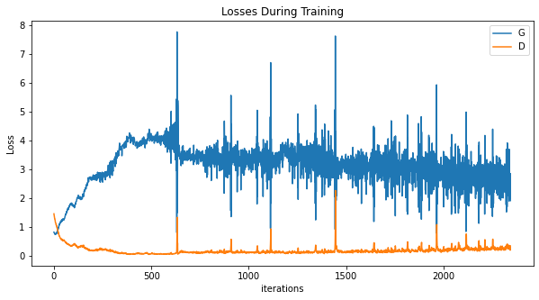

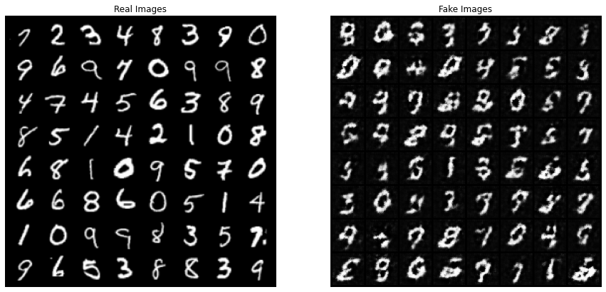

```python
# plot the loss for generator and discriminator
plot_GAN_loss([G_losses, D_losses], ["G", "D"])

# Grab a batch of real images from the dataloader
plot_real_fake_images(next(iter(dataloader)), img_list)
```